# Project1 Yu Tong yt2594

In this project, we are going to explore the ‘story’ behind the inauguation speeches of american presidents.

# Phase 1: Data Preparation

Step 1: Create a data frame that contains information of speeches.

```r
# Required packages are already loaded
main.page <- read_html(x = "http://www.presidency.ucsb.edu/inaugurals.php")
inaug=f.speechlinks(main.page) # cited from the "wk2-Tutorial-TextMining"
dat = as.Date(inaug[,1], format="%B %e, %Y")
inaug=inaug[-nrow(inaug),]
inaug.list=read.csv("../data/inauglist.csv", stringsAsFactors = FALSE)
inaug.list$Date <- dat[1:58]
inaug.list$urls <- inaug$urls
inaug.list$fulltext=NA
for(i in seq(nrow(inaug.list))) {
  text <- read_html(inaug.list$urls[i]) %>%
    html_nodes(".displaytext") %>%
    html_text()
  inaug.list$fulltext[i]=text
  filename <- paste0("../data/InauguralSpeeches/",
                     "inaug",
                     inaug.list$File[i], "-",
                     inaug.list$Term[i], ".txt")
  sink(file = filename) %>%
  cat(text)
  sink()
}
write.csv(inaug.list,file="/Users/warabe/Documents/GitHub/Spring2018-Project1-Tonyfer/output/wholeinauglist.csv")
```

The first 10 lines of datafrme ‘inaug.list’ are:

```r
head(inaug.list, 10)
```

|  | President | File | Term | Party | Date | Words | Win | urls | fulltext |
| --- | --- | --- | --- | --- | --- | --- | --- | --- | --- |
| 1 | George Washington | GeorgeWashington | 1 | NA | 1789-04-30 | 1431 | Yes | http://www.presidency.ucsb.edu/ws/index.php?pid=25800 | Fellow-Citizens of the Senate and of the House of Representatives:Among the vicissitudes incident to life no event could have filled me with greater anxieties than that of which the notification was t… |
| 2 | George Washington | GeorgeWashington | 2 | NA | 1793-03-04 | 135 | Yes | http://www.presidency.ucsb.edu/ws/index.php?pid=25801 | Fellow Citizens:I AM again called upon by the voice of my country to execute the functions of its Chief Magistrate. When the occasion proper for it shall arrive, I shall endeavor to express the high s… |
| 3 | John Adams | JohnAdams | 1 | Fedralist | 1797-03-04 | 2321 | Yes | http://www.presidency.ucsb.edu/ws/index.php?pid=25802 | WHEN it was first perceived, in early times, that no middle course for America remained between unlimited submission to a foreign legislature and a total independence of its claims, men of reflection … |
| 4 | Thomas Jefferson | ThomasJefferson | 1 | Democratic-Republican Party | 1801-03-04 | 1730 | Yes | http://www.presidency.ucsb.edu/ws/index.php?pid=25803 | Friends and Fellow-Citizens:CALLED upon to undertake the duties of the first executive office of our country, I avail myself of the presence of that portion of my fellow-citizens which is here assembl… |
| 5 | Thomas Jefferson | ThomasJefferson | 2 | Democratic-Republican Party | 1805-03-04 | 2166 | Yes | http://www.presidency.ucsb.edu/ws/index.php?pid=25804 | PROCEEDING, fellow-citizens, to that qualification which the Constitution requires before my entrance on the charge again conferred on me, it is my duty to express the deep sense I entertain of this n… |
| 6 | James Madison | JamesMadison | 1 | Democratic-Republican Party | 1809-03-04 | 1177 | Yes | http://www.presidency.ucsb.edu/ws/index.php?pid=25805 | Unwilling to depart from examples of the most revered authority, I avail myself of the occasion now presented to express the profound impression made on me by the call of my country to the station to … |
| 7 | James Madison | JamesMadison | 2 | Democratic-Republican Party | 1813-03-04 | 1211 | Yes | http://www.presidency.ucsb.edu/ws/index.php?pid=25806 | About to add the solemnity of an oath to the obligations imposed by a second call to the station in which my country heretofore placed me, I find in the presence of this respectable assembly an opport… |
| 8 | James Monroe | JamesMonroe | 1 | Democratic-Republican Party | 1817-03-04 | 3375 | Yes | http://www.presidency.ucsb.edu/ws/index.php?pid=25807 | I should be destitute of feeling if I was not deeply affected by the strong proof which my fellow-citizens have given me of their confidence in calling me to the high office whose functions I am about… |
| 9 | James Monroe | JamesMonroe | 2 | Democratic-Republican Party | 1821-03-04 | 4472 | Yes | http://www.presidency.ucsb.edu/ws/index.php?pid=25808 | Fellow-Citizens:I shall not attempt to describe the grateful emotions which the new and very distinguished proof of the confidence of my fellow-citizens, evinced by my reelection to this high trust, h… |
| 10 | John Quincy Adams | JohnQuincyAdams | 1 | Democratic-Republican Party | 1825-03-04 | 2915 | Yes | http://www.presidency.ucsb.edu/ws/index.php?pid=25809 | In compliance with an usage coeval with the existence of our Federal Constitution, and sanctioned by the example of my predecessors in the career upon which I am about to enter, I appear, my fellow-ci… |

Step 2: Prepare data for wordcloud and tf-idf

Read in speeches:

```r
folder.path= "/Users/warabe/Documents/GitHub/Spring2018-Project1-Tonyfer/data/InauguralSpeeches/"
speeches=list.files(path = folder.path, pattern = "*.txt")
prex.out=substr(speeches, 6, nchar(speeches)-4)
ff.all<-Corpus(DirSource(folder.path))
```

Processing speeches:remove extra white space, convert all letters to the lower case, remove [stop words], removed empty words due to formatting errors, and remove punctuation.

```r
ff.all<-tm_map(ff.all, stripWhitespace)
ff.all<-tm_map(ff.all, content_transformer(tolower))
ff.all<-tm_map(ff.all, removeWords, stopwords("english"))
ff.all<-tm_map(ff.all, removeWords, character(0))
ff.all<-tm_map(ff.all, removePunctuation)
tdm.all<-TermDocumentMatrix(ff.all)
tdm.tidy=tidy(tdm.all)
tdm.overall=summarise(group_by(tdm.tidy, term), sum(count))
```

# Phase 2: Data Visualization

Step 1: Create wordcloud for all the speeches:

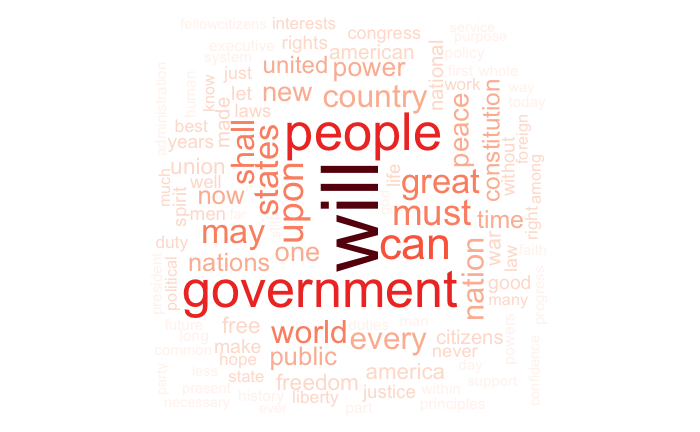

```r
wordcloud(tdm.overall$term, tdm.overall$`sum(count)`,
          scale=c(5,0.5),
          max.words=100,
          min.freq=1,
          random.order=FALSE,
          rot.per=0.3,
          use.r.layout=T,
          random.color=FALSE,
          colors=brewer.pal(9,"Reds"))
```

We can see from this wordcloud that the top three most frequent words are “will”, “people” and “government”, it shows that the inauguation speeches are mostly about the promise that presidents made to the public.

Step 2: Interactive visualize important words in individual speeches

```r
library(shiny)
```

```r
shinyApp(
    ui = fluidPage(
      fluidRow(style = "padding-bottom: 20px;",
        column(4, selectInput('speech1', 'Speech 1', speeches, selected=speeches[5])),
        column(4, selectInput('speech2', 'Speech 2', speeches, selected=speeches[9])),
        column(4, sliderInput('nwords', 'Number of words', 3, min = 20,
                              max = 200, value=100, step = 20))
      ),
      fluidRow(
        plotOutput('wordclouds', height = "400px")
      )
    ),
    server = function(input, output, session) {
      # Combine the selected variables into a new data frame
      selectedData <- reactive({
        list(dtm.term1=ff.dtm$term[ff.dtm$document==as.character(which(speeches == input$speech1))],
             dtm.count1=ff.dtm$count[ff.dtm$document==as.character(which(speeches == input$speech1))],
             dtm.term2=ff.dtm$term[ff.dtm$document==as.character(which(speeches == input$speech2))],
             dtm.count2=ff.dtm$count[ff.dtm$document==as.character(which(speeches == input$speech2))])
      })
      output$wordclouds <- renderPlot(height = 400, {
        par(mfrow=c(1,2), mar = c(0, 0, 3, 0))
        wordcloud(selectedData()$dtm.term1,
                  selectedData()$dtm.count1,
              scale=c(4,0.5),
              max.words=input$nwords,
              min.freq=1,
              random.order=FALSE,
              rot.per=0,
              use.r.layout=FALSE,
              random.color=FALSE,
              colors=brewer.pal(10,"Blues"),
            main=input$speech1)
        wordcloud(selectedData()$dtm.term2,
                  selectedData()$dtm.count2,
              scale=c(4,0.5),
              max.words=input$nwords,
              min.freq=1,
              random.order=FALSE,
              rot.per=0,
              use.r.layout=FALSE,
              random.color=FALSE,
              colors=brewer.pal(10,"Blues"),
            main=input$speech2)
      })
    },
    options = list(height = 600)
)
```

```
Listening on http://127.0.0.1:5061
```

# Phase 3: Use clustering analysis to cluster single words.

Because in one speech, the speaker always use some words that refer to similiar meaning, we can use clustering analysis to find out similiar words.

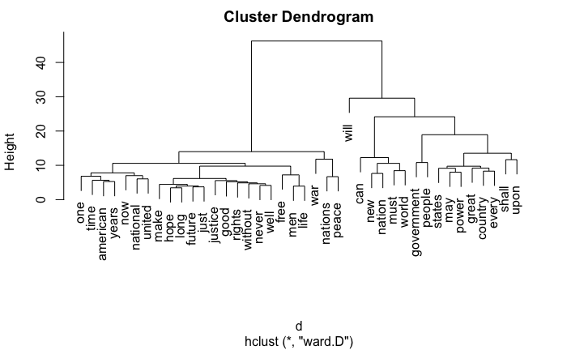

```r
tdm_removed<-removeSparseTerms(tdm.all, 0.25) # Because there are totally 9403 words, it's too much for the plot, we just choose some frequent term of them.
mydata <- as.data.frame(as.matrix(tdm_removed))
mydata.scale<-scale(mydata)
d<-dist(mydata.scale,method="euclidean")
fit <- hclust(d, method="ward.D")
plot(fit)
```

# Phase 4: Sentimental Analysis of Each Speech

Step 1: Create sentences list

```r
sentence.list <- NULL
for(i in 1:nrow(inaug.list)){
  sentences <- sent_detect(inaug.list$fulltext[i],
                        endmarks = c("?", ".", "!", "|",";"))
  if(length(sentences)>0){
    emotions=get_nrc_sentiment(sentences)
    word.count=word_count(sentences)
    #colnames(emotions)=paste0("emo.", colnames(emotions))
    # in case the word counts are zeros?
    emotions=diag(1/(word.count+0.01))%*%as.matrix(emotions)
    sentence.list=rbind(sentence.list,
                        cbind(inaug.list[i,-ncol(inaug.list)],
                              sentences=as.character(sentences),
                              word.count,
                              emotions,
                              sent.id=1:length(sentences)
                              )
    )
  }
}
sentence.list <- sentence.list%>%filter(!is.na(word.count))
```

Step 2: Clustering of emotions

Since we already get the emotion of each sentence. We can do clustering for the speeches.

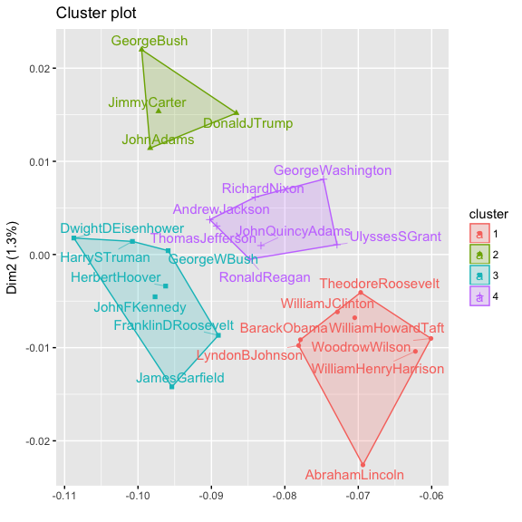

```r
presid.summary=tbl_df(sentence.list)%>%
  filter(File%in%sel.comparison)%>%
  #group_by(paste0(type, File))%>%
  group_by(File)%>%
  summarise(
    anger=mean(anger),
    anticipation=mean(anticipation),
    disgust=mean(disgust),
    fear=mean(fear),
    joy=mean(joy),
    sadness=mean(sadness),
    surprise=mean(surprise),
    trust=mean(trust)
    #negative=mean(negative),
    #positive=mean(positive)
  )
presid.summary=as.data.frame(presid.summary)
for(i in 2:9){
  presid.summary[,i][is.na(presid.summary[,i])] = 0
}
rownames(presid.summary)=as.character((presid.summary[,1]))
km.res=kmeans(presid.summary[,-1], iter.max=200,
              4)
fviz_cluster(km.res,
             stand=F, repel= TRUE,
             data = presid.summary[,-1], xlab="", xaxt="n",
             show.clust.cent=FALSE)
```

# Phase 5: Use topic model to analyze speeches

Instead of analyze every three sentences of the speeches, I use topic model to analyze the wholie speech.

Step 1: Data preparation

```r
docs <- Corpus(VectorSource(inaug.list$fulltext))
docs <-tm_map(docs,content_transformer(tolower))
docs <- tm_map(docs, removePunctuation)
docs <- tm_map(docs, removeNumbers)
docs <- tm_map(docs, removeWords, stopwords("english"))
docs <- tm_map(docs, stripWhitespace)
docs <- tm_map(docs,stemDocument)
```

Step 2: Use LDA(Latent Dirichlet Allocation) analyze the topic of speeches

```r
dtm <- DocumentTermMatrix(docs)
dtm  <- dtm[rowTotals> 0, ]
```

```r
burnin <- 5000
iter <- 2500
thin <- 500
seed <-list(2003,5,63,100001,765)
nstart <- 5
best <- TRUE
k <- 15
ldaOut <-LDA(dtm, k, method="Gibbs", control=list(nstart=nstart,
                                                 seed = seed, best=best,
                                                 burnin = burnin, iter = iter,
                                                 thin=thin))
ldaOut.topics <- as.matrix(topics(ldaOut))
table(c(1:k, ldaOut.topics))
```

```
 1  2  3  4  5  6  7  8  9 10 11 12 13 14 15
33  2  1  1  1  2 11  1  1  1  2  2  1 12  2
```

```r
write.csv(ldaOut.topics,file=paste("../output/LDAGibbs",k,"DocsToTopics.csv"))
ldaOut.terms <- as.matrix(terms(ldaOut,20))
write.csv(ldaOut.terms,file=paste("../output/LDAGibbs",k,"TopicsToTerms.csv"))
topicProbabilities <- as.data.frame(ldaOut@gamma)
write.csv(topicProbabilities,file=paste("../output/LDAGibbs",k,"TopicProbabilities.csv"))
```

```r
terms.beta=ldaOut@beta
terms.beta=scale(terms.beta)
topics.terms=NULL
for(i in 1:k){
  topics.terms=rbind(topics.terms, ldaOut@terms[order(terms.beta[i,], decreasing = TRUE)[1:7]])
}
topics.terms
```

```
      [,1]           [,2]        [,3]         [,4]          [,5]         [,6]
 [1,] "maintain"     "practic"   "conduct"    "affair"      "attent"     "sever"
 [2,] "heard"        "limitless" "breez"      "reaffirm"    "unknown"    "disappear"
 [3,] "besid"        "church"    "desert"     "monument"    "hill"       "hero"
 [4,] "pictur"       "crowd"     "globe"      "counten"     "insurg"     "draft"
 [5,] "various"      "rever"     "council"    "indulg"      "saw"        "religion"
 [6,] "opinion"      "harmoni"   "intrust"    "prescrib"    "intercours" "occur"
 [7,] "learn"        "strive"    "washington" "program"     "leader"     "summon"
 [8,] "slaveri"      "slave"     "expressli"  "pretext"     "exig"       "claus"
 [9,] "commenc"      "late"      "augment"    "fortif"      "exploit"    "defici"
[10,] "unwil"        "profess"   "undertaken" "valley"      "treatment"  "doom"
[11,] "agenc"        "concept"   "recoveri"   "mandat"      "reign"      "ownership"
[12,] "relationship" "sanctiti"  "successor"  "interdepend" "proven"     "inspir"
[13,] "bosom"        "similar"   "district"   "consent"     "contend"    "complain"
[14,] "america"      "heal"      "journey"    "founder"     "vice"       "dream"
```

[output cut: 17 more lines]

```r
ldaOut.terms
```

```
      Topic 1    Topic 2   Topic 3       Topic 4      Topic 5      Topic 6         Topic 7
 [1,] "will"     "thing"   "economi"     "guid"       "mind"       "govern"        "nation"
 [2,] "peopl"    "men"     "tax"         "alik"       "stand"      "state"         "world"
 [3,] "upon"     "day"     "day"         "mighti"     "servic"     "union"         "can"
 [4,] "nation"   "life"    "destroy"     "along"      "various"    "constitut"     "freedom"
 [5,] "govern"   "like"    "back"        "scienc"     "counsel"    "power"         "peopl"
 [6,] "great"    "great"   "begin"       "blood"      "exampl"     "preserv"       "peac"
 [7,] "countri"  "good"    "feder"       "stranger"   "first"      "institut"      "must"
 [8,] "can"      "hand"    "done"        "honest"     "univers"    "form"          "hope"
 [9,] "may"      "see"     "opportun"    "sum"        "integr"     "opinion"       "know"
[10,] "shall"    "part"    "return"      "drawn"      "acknowledg" "protect"       "free"
[11,] "public"   "look"    "dare"        "pray"       "gratitud"   "exist"         "human"
[12,] "duti"     "wealth"  "doubt"       "friend"     "virtu"      "object"        "live"
[13,] "state"    "whether" "issu"        "globe"      "religion"   "author"        "need"
[14,] "everi"    "cost"    "hero"        "pass"       "public"     "one"           "come"
```

[output cut: 48 more lines]

Step 3: Clustering of topics

```r
par(mar=c(1,1,1,1))
topic.summary=tbl_df(inaug.list.df)%>%
              select(File, Economy:Legislation)%>%
              group_by(File)%>%
              summarise_each(funs(mean))
```

```
`summarise_each()` is deprecated.
Use `summarise_all()`, `summarise_at()` or `summarise_if()` instead.
To map `funs` over all variables, use `summarise_all()`
```

```r
topic.summary=as.data.frame(topic.summary)
rownames(topic.summary)=topic.summary[,1]
topic.plot=c(1, 13, 9, 11, 8, 3, 7)
print(topics.hash[topic.plot])
```

```
[1] "Economy"         "Equality"        "Reform"          "WorkingFamilies" "Government"
[6] "Defense"         "Unity"
```

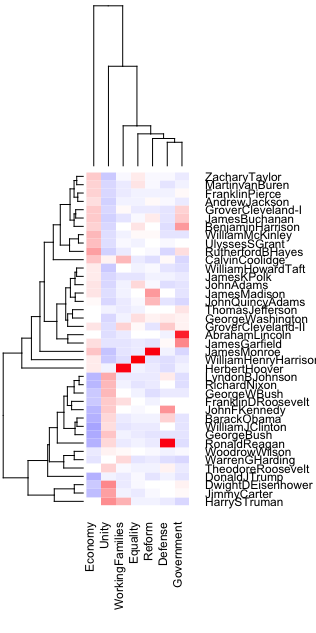

```r
heatmap.2(as.matrix(topic.summary[,topic.plot+1]),
          scale = "column", key=F,
          col = bluered(100),
          cexRow = 0.9, cexCol = 0.9, margins = c(8, 8),
          trace = "none", density.info = "none")
```

Step 4: Clustering thespeeches based on the topics

```r
presid.summary=tbl_df(inaug.list.df)%>%
  filter(File%in%sel.comparison)%>%
  select(File, Economy:Legislation)%>%
  group_by(File)%>%
  summarise_each(funs(mean))
```

```
`summarise_each()` is deprecated.
Use `summarise_all()`, `summarise_at()` or `summarise_if()` instead.
To map `funs` over all variables, use `summarise_all()`
```

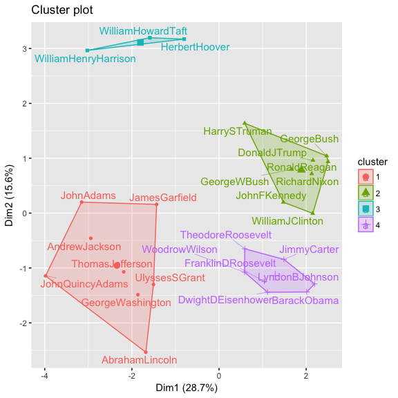

```r
presid.summary=as.data.frame(presid.summary)
rownames(presid.summary)=as.character((presid.summary[,1]))
km.res=kmeans(scale(presid.summary[,-1]), iter.max=200,
              4)
fviz_cluster(km.res,
             stand=T, repel= TRUE,
             data = presid.summary[,-1],
             show.clust.cent=T)
```

# Phase 6: Find the nearest neighberhood of a speech

By using tf-idf, we can compute the cosine distance and the euclidean distance of every two speeches. Then we can analyze the similiarity of the speech and its neighbors.

Step 1: Compute tf-idf

```r
dtm <- DocumentTermMatrix(ff.all,
                          control = list(weighting = function(x)
                                             weightTfIdf(x,
                                                         normalize =FALSE),
                                         stopwords = TRUE))
```

Step 2: Compute two kinds of ditances

```r
mat <- as.matrix(dtm)
i <- 1:2
j <- 1:2
distance.sqr <- 1:2
dis.sqr <- data.frame(i,j,distance.sqr)
for(i in 1:58){
  for(j in 1:58){
     x <- mat[i, ]
     y <- mat[j, ]
     d <- sqrt(sum((x-y)^2))
     dis.sqr[(i-1)*58 + j, 1] <- i
     dis.sqr[(i-1)*58 + j, 2] <- j
     dis.sqr[(i-1)*58 + j, 3] <- d
  }
}
i <- 1:2
j <- 1:2
distance.cos <- 1:2
dis.cos <- data.frame(i,j,distance.cos)
for(i in 1:58){
  for(j in 1:58){
     x <- mat[i, ]
     y <- mat[j, ]
     d <- sum(x*y)/(sqrt(sum(x^2)))/(sqrt(sum(y^2)))
     dis.cos[(i-1)*58 + j, 1] <- i
     dis.cos[(i-1)*58 + j, 2] <- j
     dis.cos[(i-1)*58 + j, 3] <- d
  }
}
```

Step 3: Define a function ‘get_query’ to output the nearest neighborhoods of document.

```r
get_query <- function(president, term, distance){
  sort.ina <- inaug.list[order(inaug.list$President), c(1,3,4,5,6)]
  t = which(sort.ina$President == president)[term]
  if(distance == "sqr"){
    sub <- dis.sqr[dis.sqr$i == t,]
    sub <- sub[order(sub$distance.sqr, decreasing = F), ]
    return(sort.ina[sub$j[1:6], ])
  }
  if(distance == "cos"){
    sub <- dis.cos[dis.cos$i == t,]
    sub <- sub[order(sub$distance.cos, decreasing = T), ]
    return(sort.ina[sub$j[1:6], ])
  }
}
```

For eample,

```r
get_query("Abraham Lincoln", 1, "cos")
```

|  | President | Term | Party | Date | Words |
| --- | --- | --- | --- | --- | --- |
| 19 | Abraham Lincoln | 1 | Republican | 1861-03-04 | 3637 |
| 14 | William Henry Harrison | 1 | Whig | 1841-03-04 | 8460 |
| 15 | James K. Polk | 1 | Democratic | 1845-03-04 | 4809 |
| 18 | James Buchanan | 1 | Democratic | 1857-03-04 | 2831 |
| 24 | James Garfield | 1 | Republican | 1881-03-04 | 2979 |
| 23 | Rutherford B. Hayes | 1 | Republican | 1877-03-05 | 2486 |

```r
get_query("Abraham Lincoln", 1, "sqr")
```

|  | President | Term | Party | Date | Words |
| --- | --- | --- | --- | --- | --- |
| 19 | Abraham Lincoln | 1 | Republican | 1861-03-04 | 3637 |
| 55 | George W. Bush | 2 | Republican | 2005-01-20 | 2071 |
| 40 | Franklin D. Roosevelt | 4 | Democratic | 1945-01-20 | 559 |
| 16 | Zachary Taylor | 1 | Whig | 1849-03-05 | 1090 |
| 12 | Andrew Jackson | 2 | Democratic | 1833-03-04 | 1176 |
| 20 | Abraham Lincoln | 2 | Republican | 1865-03-04 | 700 |

```r
get_query("George W. Bush", 2, "sqr")
```

|  | President | Term | Party | Date | Words |
| --- | --- | --- | --- | --- | --- |
| 55 | George W. Bush | 2 | Republican | 2005-01-20 | 2071 |
| 40 | Franklin D. Roosevelt | 4 | Democratic | 1945-01-20 | 559 |
| 30 | Theodore Roosevelt | 1 | Republican | 1905-03-04 | 984 |
| 16 | Zachary Taylor | 1 | Whig | 1849-03-05 | 1090 |
| 20 | Abraham Lincoln | 2 | Republican | 1865-03-04 | 700 |
| 12 | Andrew Jackson | 2 | Democratic | 1833-03-04 | 1176 |

```r
get_query("George W. Bush", 2, "cos")
```

|  | President | Term | Party | Date | Words |
| --- | --- | --- | --- | --- | --- |
| 55 | George W. Bush | 2 | Republican | 2005-01-20 | 2071 |
| 25 | Grover Cleveland - I | 1 | Democratic | 1885-03-04 | 1686 |
| 19 | Abraham Lincoln | 1 | Republican | 1861-03-04 | 3637 |
| 18 | James Buchanan | 1 | Democratic | 1857-03-04 | 2831 |
| 14 | William Henry Harrison | 1 | Whig | 1841-03-04 | 8460 |
| 15 | James K. Polk | 1 | Democratic | 1845-03-04 | 4809 |

```r
get_query("George Bush", 1, "sqr")
```

|  | President | Term | Party | Date | Words |
| --- | --- | --- | --- | --- | --- |
| 51 | George Bush | 1 | Republican | 1989-01-20 | 2320 |
| 55 | George W. Bush | 2 | Republican | 2005-01-20 | 2071 |
| 40 | Franklin D. Roosevelt | 4 | Democratic | 1945-01-20 | 559 |
| 30 | Theodore Roosevelt | 1 | Republican | 1905-03-04 | 984 |
| 16 | Zachary Taylor | 1 | Whig | 1849-03-05 | 1090 |
| 20 | Abraham Lincoln | 2 | Republican | 1865-03-04 | 700 |